# Practical 4: Visualisation using qplot()

Laura Rodriguez Navas

February 2020

Keratoconus is a disorder that affects the cornea through an abnormal growth of collagen fibres. This makes the cornea become conical with an important vision loss. There are many possible treatments, but one common solution is the insertion of intrastromal corneal ring segments, such that the cornea is flattened.

The file “queratocono.csv” includes information about 394 patients with Keratoconus who were treated with ring placement. The variables that were recorded are:

1. K1: keratometry or main corneal curvature.
2. K2: perpendicular curvature to K1.
3. Ch: corneal hysteresis.
4. Na: number of rings (1 or 2).
5. Incision: angle in which the cornea is cut.
6. Prof: depth of the incision.
7. Diam: diameter of the incision.
8. Grosor: Incision thickness.
9. Longitud1: Angle of placement of the first ring (surgical parameter).
10. Longitud2: Angle of placement of the second ring (surgical parameter).
11. grosor1: Thickness of the first ring.
12. grosor2: Thickness of the second ring.
13. long1: arc length of the first ring.
14. long2: arc length of the second ring.
15. K1.salida: keratometry or main corneal curvature after the placement of the ring(s).
16. Astig: astigmatism curvature after the placement of the ring(s) (K1.salida – K2.salida).

## Data Preparation

Check that there is no NA value.

```r
any(is.na(queratocono))
```

```
## [1] FALSE
```

The data in the dataset is sorted by column na.

```r
queratocono <- queratocono[order(queratocono$na), ]
str(queratocono)
```

```
## 'data.frame':    394 obs. of  16 variables:
##  $ K1       : num  45.7 44.2 44.2 53.1 40.7 35.4 51.5 40.6 49.5 44.9 ...
##  $ K2       : num  50.1 44.8 45.8 53.8 44.5 42 55.4 45.4 53.7 47.5 ...
##  $ ch       : num  11.1 8.9 11.1 7.5 9.4 8.2 10.1 8.6 7.2 7.6 ...
##  $ na       : int  1 1 1 1 1 1 1 1 1 1 ...
##  $ Incision : int  30 180 130 60 30 170 165 30 180 60 ...
##  $ Prof     : int  370 327 380 400 477 420 400 400 434 367 ...
##  $ diam     : int  5 6 6 5 5 5 6 6 5 5 ...
##  $ grosor   : int  250 200 200 200 200 250 200 250 200 200 ...
##  $ Longitud1: int  160 150 210 160 160 160 150 150 210 160 ...
##  $ Longitud2: int  160 150 210 160 160 160 150 150 210 160 ...
##  $ grosor1  : int  250 200 200 200 200 250 200 250 200 200 ...
##  $ grosor2  : int  0 0 0 0 0 0 0 0 0 0 ...
##  $ long1    : int  160 150 210 160 160 160 150 150 210 160 ...
##  $ long2    : int  0 0 0 0 0 0 0 0 0 0 ...
##  $ K1.salida: num  45.8 42.8 43.1 48.7 39.8 35.6 48.7 42.7 47.4 43.7 ...
##  $ Astig    : num  1.9 2.3 3.9 2.8 3.8 4 5.3 1.2 0.3 1.8 ...
```

## Data Visualisation

In order to analyse the information in a visual way:

1. Study the relation between K1 and K2 with smoother (by default and using linear regression).

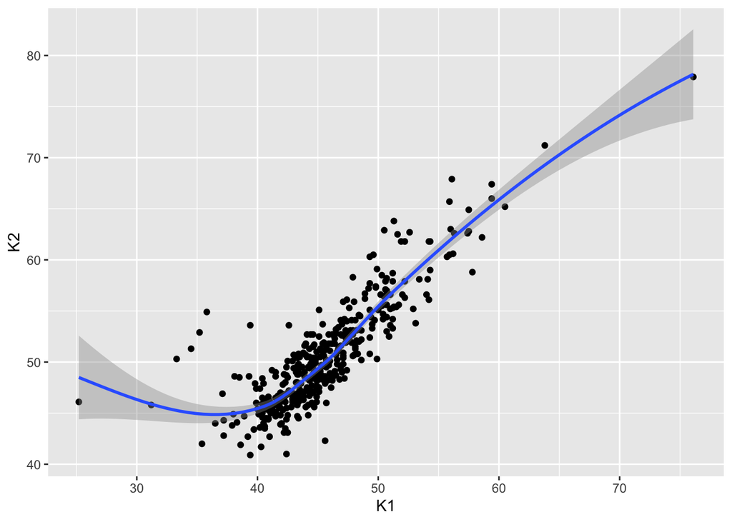

```r
qplot(K1, K2, data = queratocono) +
  geom_point(size = 0.1) +
  geom_smooth(method = "loess") +
  xlab("K1") + ylab("K2")
```

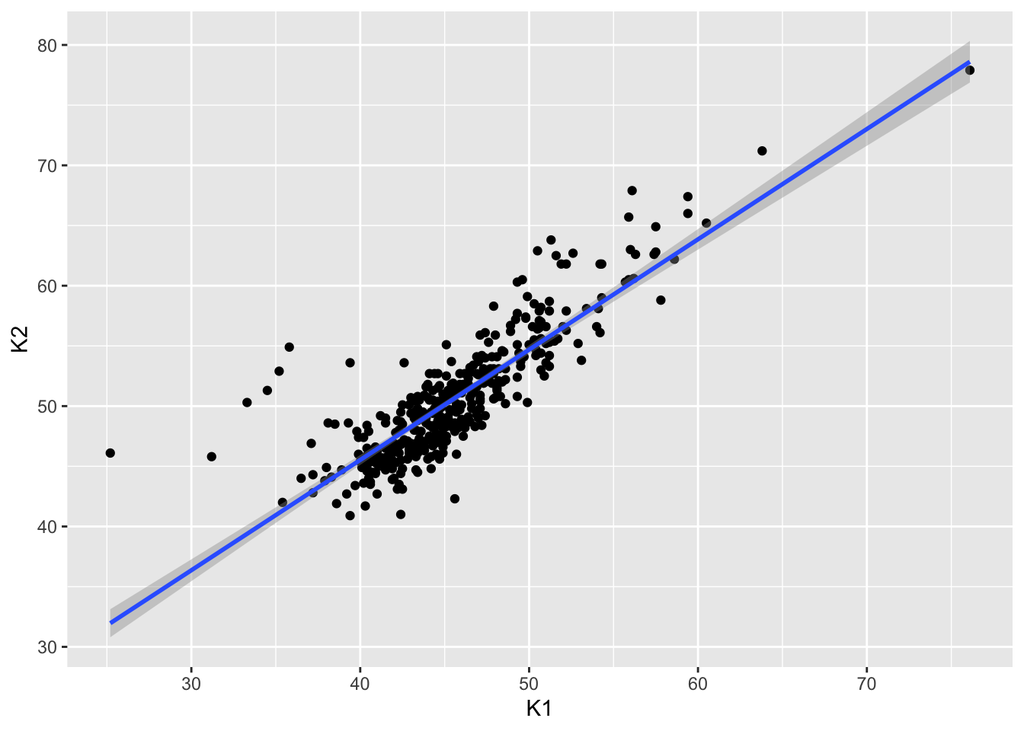

```r
qplot(K1, K2, data = queratocono) +
  geom_point(size = 0.1) +
  geom_smooth(method = lm) +
  xlab("K1") + ylab("K2")
```

2. Study the relation between K1 and K2 distinguishing by factor na.

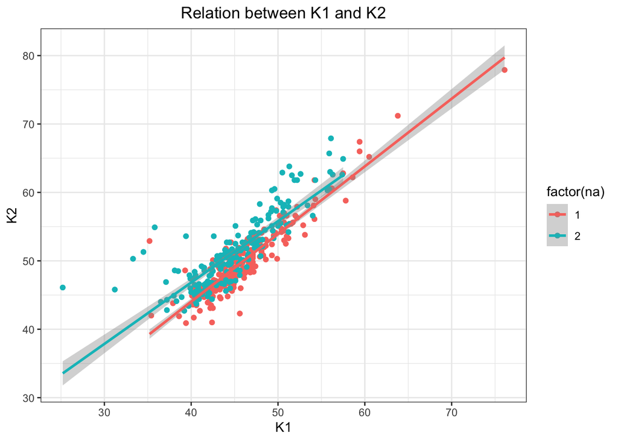

```r
qplot(K1, K2, data = queratocono, colour = factor(na)) +
  geom_point() +
  geom_smooth(method = lm) +
  xlab("K1") + ylab("K2") +
  ggtitle("Relation between K1 and K2") +
  theme_bw() +
  theme(plot.title = element_text(hjust = 0.5))
```

3. Study the relation between K1 and K1.salida.

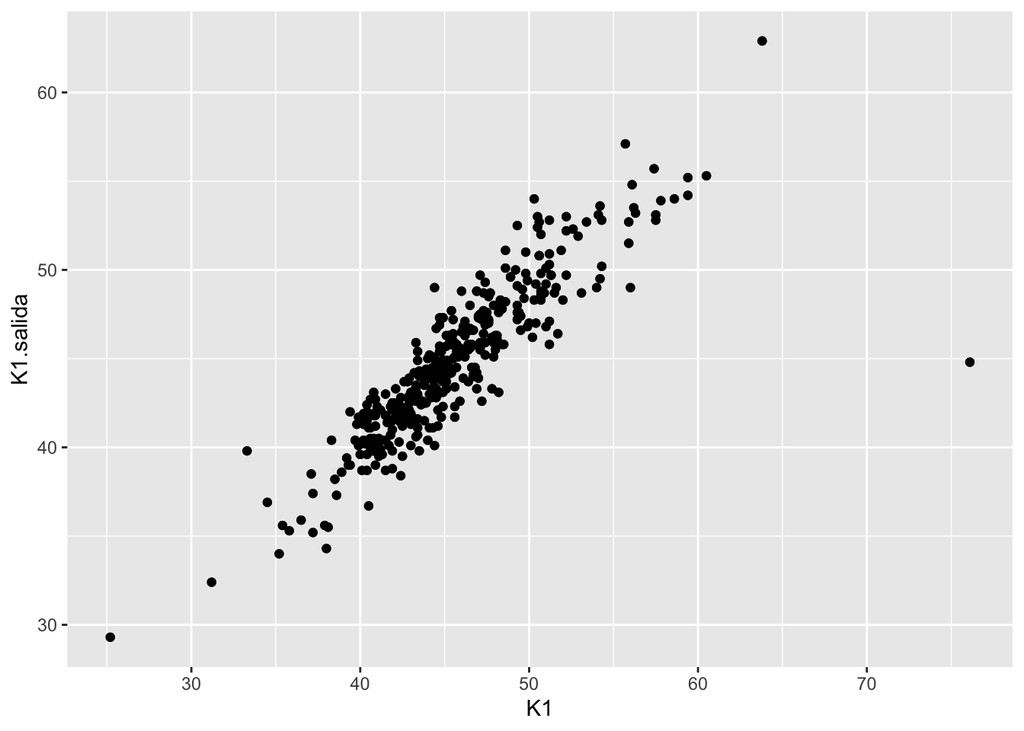

```r
qplot(K1, K1.salida, data = queratocono) +
  geom_point() +
  xlab("K1") + ylab("K1.salida")
```

4. Build a histogram in terms of grosor (note that grosor should be taken as a factor) of the inserted ring.

The way qplot color codes the bars is opposite to how the colors are displayed in the legend. It can be resolve this two different ways; either reversing the legend or specify the direction of the levels when transforming the transmission (na) variable into a factor. Both align the legend color coding layout to the color coding of the stacked bars and also determine which color is top versus on the bottom.

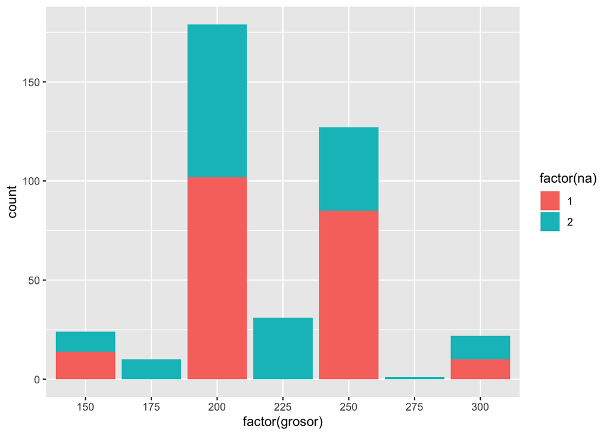

```r
qplot(factor(grosor), data = queratocono, geom = "bar", fill = factor(na, levels = c(2, 1))) +
  guides(fill = guide_legend(reverse = TRUE)) +
  scale_fill_manual(values = c("#00BFC4", "#F8766D")) +
  labs(fill = "factor(na)") +
  ylab("count")
```

Manually the name of ylab has been changed since the method of qplot stat = “count” is deprecated. It is used by default but does not show the name in the graph, as the method of ggplot does.

5. Build a scatter plot of the relation between K1 and K2 with “faceting” in terms of the parameters diam and na, by assigning different colours to the points according to the thickness (grosor) of the ring. In order to visualise all points correctly use a transparency of value 1/3.

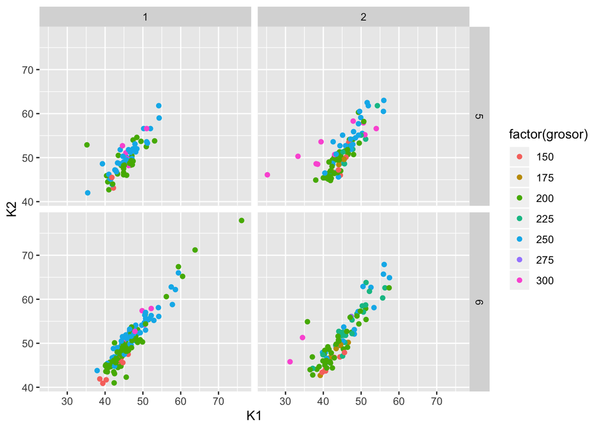

```r
qplot(K1, K2, data = queratocono, colour = factor(grosor), facets = diam ~ na,
      size = I(1/3)) +
      geom_point() +
      scale_shape_manual(values = 0:7) +
      xlab("K1") + ylab("K2")
```

6. Create two boxplots that show a summary of the distributions of K1 and K2 (separately) with respect to the thickness (grosor).

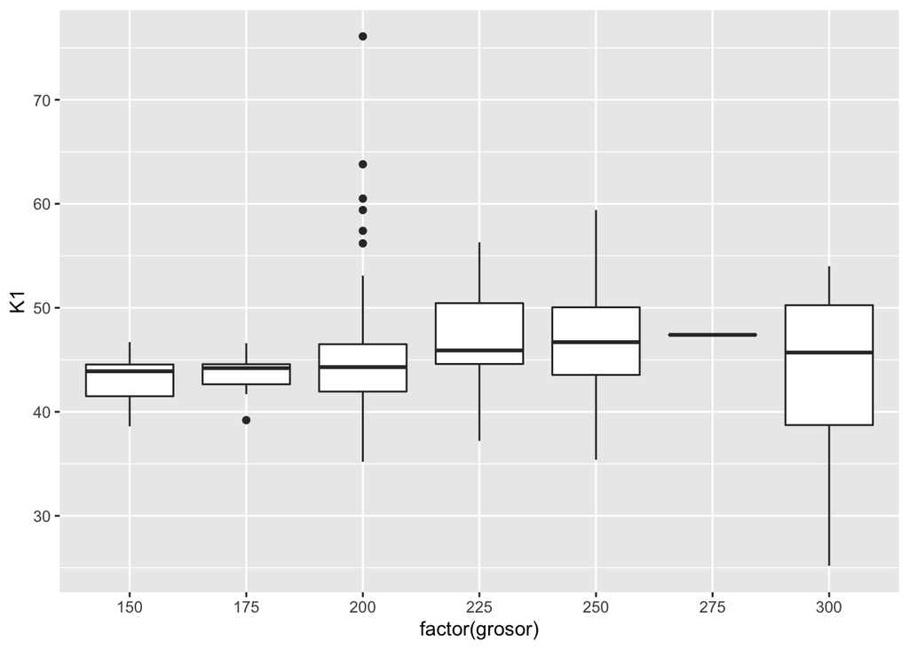

```r
qplot(factor(grosor), K1, data = queratocono, geom = "boxplot") +
  xlab("factor(grosor)") + ylab("K1")
```

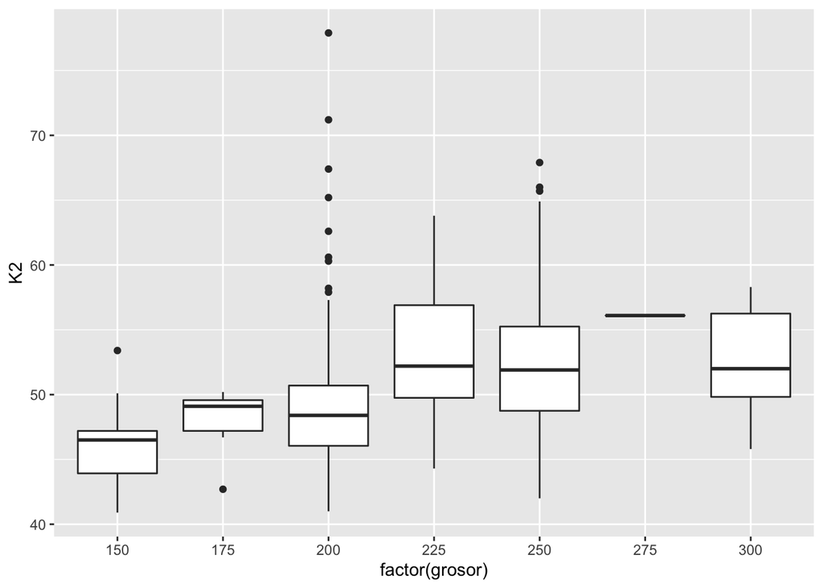

```r
qplot(factor(grosor), K2, data = queratocono, geom = "boxplot") +
  xlab("factor(grosor)") + ylab("K2")
```